# EUs vs Toms MAGs parsing and plotting

This notebook the results of the `euvsmags_mapping.Rmd`.

## Set Environment

```r
library(tidyverse)
library(scales)
```

Download files from MAGs produce by Tom Delmont [here](http://merenlab.org/data/2017_Delmont_et_al_HBDs/).

```bash
cd ~/Downloads

wget http://files.metagenomics.eu/TARA_non_redundant_MAGs_AA.fa.gz
wget http://files.metagenomics.eu/TARA_MAGs_v3_metadata.txt
wget http://files.metagenomics.eu/orf2mag.tsv.gz
wget http://files.metagenomics.eu/tara_delmont_taxids.csv
```

## Read in files

| gene_callers_id | clstr_ID | id | evalue | unk_id |
| --- | --- | --- | --- | --- |
| 12971 | 23915488 | 1.000 | 1.04e-109 | 23915488 |
| 25421 | 30632866 | 0.728 | 7.88e-131 | 30632866 |
| 28862 | 6516700 | 0.911 | 1.47e-83 | 6516700 |
| 28898 | 30067678 | 0.846 | 8.60e-103 | 30067678 |
| 32423 | 25294676 | 0.798 | 1.06e-250 | 25294676 |
| 32437 | 9635122 | 0.785 | 7.09e-41 | 9635122 |
| 35355 | 3386980 | 0.940 | 9.38e-92 | 3386980 |
| 41254 | 7810948 | 0.693 | 1.90e-62 | 7810948 |
| 43544 | 25210318 | 0.854 | 2.43e-83 | 25210318 |
| 49308 | 13291311 | 0.350 | 6.06e-30 | 13291311 |

[output cut: 990 more lines]

## Clean data

|  | gene_callers_id | clstr_ID | id | evalue | unk_id | component | MAG |
| --- | --- | --- | --- | --- | --- | --- | --- |
| 1 | 12971 | 23915488 | 1.000 | 1.04e-109 | 23915488 | eu_comp_18248 | TARA_ANE_MAG_00007 |
| 2 | 25421 | 30632866 | 0.728 | 7.88e-131 | 30632866 | eu_comp_183881 | TARA_ANE_MAG_00012 |
| 3 | 28862 | 6516700 | 0.911 | 1.47e-83 | 6516700 | eu_comp_64099 | TARA_ANE_MAG_00014 |
| 4 | 28898 | 30067678 | 0.846 | 8.60e-103 | 30067678 | eu_comp_82230 | TARA_ANE_MAG_00014 |
| 5 | 32423 | 25294676 | 0.798 | 1.06e-250 | 25294676 | eu_comp_227609 | TARA_ANE_MAG_00016 |
| 6 | 32437 | 9635122 | 0.785 | 7.09e-41 | 9635122 | eu_comp_185860 | TARA_ANE_MAG_00016 |
| 7 | 35355 | 3386980 | 0.940 | 9.38e-92 | 3386980 | eu_comp_187059 | TARA_ANE_MAG_00019 |
| 8 | 41254 | 7810948 | 0.693 | 1.90e-62 | 7810948 | eu_comp_7325 | TARA_ANE_MAG_00023 |
| 9 | 43544 | 25210318 | 0.854 | 2.43e-83 | 25210318 | eu_comp_228790 | TARA_ANE_MAG_00025 |
| 10 | 49308 | 13291311 | 0.350 | 6.06e-30 | 13291311 | eu_comp_736 | TARA_ANE_MAG_00028 |

[output cut: 990 more lines]

## Let’s answer some basic questions

What percentage of EU components from the TARA Ocean surface, prokaryotic metagenomes mapped to TOM’s MAGs?

```r
(m_vs_u_comp %>% select(component) %>% unique() %>% count()/clstrs_tps_stats_f2 %>% select(component) %>% unique() %>% count()) %>% as.numeric() %>% percent()
```

```
[1] "91%"
```

91% of the EU components found in the TARA Ocean surface, prokaryotic metagenomes mapped to TOM’s. This may imply that TOM’s MAGs are very representative of the prokaryotic community in the surface ocean.

Check where the 10% thats missing are!

```r
(m_vs_u_comp_mag %>% select(MAG) %>% unique() %>% count()/957) %>% as.numeric() %>% percent()
```

```
[1] "90.6%"
```

```r
m_vs_u_mag_n_25 <- m_vs_u_mag_n %>%
  dplyr::top_n(10, wt = n) %>% # n is the number of EUs components
  .$MAG
m_vs_u_mag_n %>% dplyr::top_n(10, wt = n) %>% # raw EU counts
  arrange(desc(n))
```

| MAG | n | n_orf | prop | X2 | domain | phylum | class | order | family | genus |
| --- | --- | --- | --- | --- | --- | --- | --- | --- | --- | --- |
| TARA_ANW_MAG_00076 | 1489 | 6987 | 0.2131101 | 200644 | Bacteria | Bacteroidetes | Flavobacteriia | Flavobacteriales | NA | NA |
| TARA_ANW_MAG_00087 | 934 | 3838 | 0.2433559 | 1236 | Bacteria | Proteobacteria | Gammaproteobacteria | NA | NA | NA |
| TARA_ANW_MAG_00082 | 903 | 3676 | 0.2456474 | 200644 | Bacteria | Bacteroidetes | Flavobacteriia | Flavobacteriales | NA | NA |
| TARA_PSE_MAG_00127 | 835 | 2824 | 0.2956799 | 200644 | Bacteria | Bacteroidetes | Flavobacteriia | Flavobacteriales | NA | NA |
| TARA_ASE_MAG_00025 | 798 | 6377 | 0.1251372 | 200644 | Bacteria | Bacteroidetes | Flavobacteriia | Flavobacteriales | NA | NA |
| TARA_PON_MAG_00087 | 649 | 2821 | 0.2300603 | 2 | Bacteria | NA | NA | NA | NA | NA |
| TARA_PSE_MAG_00145 | 638 | 3527 | 0.1808903 | 49546 | Bacteria | Bacteroidetes | Flavobacteriia | Flavobacteriales | Flavobacteriaceae | NA |
| TARA_PSE_MAG_00150 | 608 | 3704 | 0.1641469 | 468 | Bacteria | Proteobacteria | Gammaproteobacteria | Pseudomonadales | Moraxellaceae | NA |
| TARA_ION_MAG_00074 | 590 | 2603 | 0.2266615 | 766 | Bacteria | Proteobacteria | Alphaproteobacteria | Rickettsiales | NA | NA |
| TARA_ASE_MAG_00029 | 543 | 3360 | 0.1616071 | 89374 | Bacteria | Bacteroidetes | Saprospiria | Saprospirales | Saprospiraceae | NA |

…by proportion of EU components to total ORFs

```r
m_vs_u_mag_n %>% dplyr::top_n(10, wt = prop) %>% # proportion of EUs to ORFs
  arrange(desc(prop))
```

| MAG | n | n_orf | prop | X2 | domain | phylum | class | order | family | genus |
| --- | --- | --- | --- | --- | --- | --- | --- | --- | --- | --- |
| TARA_PSE_MAG_00127 | 835 | 2824 | 0.2956799 | 200644 | Bacteria | Bacteroidetes | Flavobacteriia | Flavobacteriales | NA | NA |
| TARA_ANW_MAG_00082 | 903 | 3676 | 0.2456474 | 200644 | Bacteria | Bacteroidetes | Flavobacteriia | Flavobacteriales | NA | NA |
| TARA_ANW_MAG_00087 | 934 | 3838 | 0.2433559 | 1236 | Bacteria | Proteobacteria | Gammaproteobacteria | NA | NA | NA |
| TARA_PON_MAG_00087 | 649 | 2821 | 0.2300603 | 2 | Bacteria | NA | NA | NA | NA | NA |
| TARA_ION_MAG_00074 | 590 | 2603 | 0.2266615 | 766 | Bacteria | Proteobacteria | Alphaproteobacteria | Rickettsiales | NA | NA |
| TARA_ANW_MAG_00076 | 1489 | 6987 | 0.2131101 | 200644 | Bacteria | Bacteroidetes | Flavobacteriia | Flavobacteriales | NA | NA |
| TARA_ANE_MAG_00069 | 409 | 2137 | 0.1913898 | 766 | Bacteria | Proteobacteria | Alphaproteobacteria | Rickettsiales | NA | NA |
| TARA_PSE_MAG_00145 | 638 | 3527 | 0.1808903 | 49546 | Bacteria | Bacteroidetes | Flavobacteriia | Flavobacteriales | Flavobacteriaceae | NA |
| TARA_PSE_MAG_00150 | 608 | 3704 | 0.1641469 | 468 | Bacteria | Proteobacteria | Gammaproteobacteria | Pseudomonadales | Moraxellaceae | NA |
| TARA_ASE_MAG_00029 | 543 | 3360 | 0.1616071 | 89374 | Bacteria | Bacteroidetes | Saprospiria | Saprospirales | Saprospiraceae | NA |

Flavobacteriia and gamma/alpha proteobacteria have the highest EU component percentage in their contigs.

What are the most represented Phylum of Tom’s MAGs that have EUs that mapped to them?

```r
m_vs_u_mag_n %>% group_by(phylum) %>% count %>% arrange(desc(nn))
```

| phylum | nn |
| --- | --- |
| Proteobacteria | 371 |
| NA | 157 |
| Bacteroidetes | 107 |
| Euryarchaeota | 65 |
| Verrucomicrobia | 60 |
| Planctomycetes | 38 |
| Chlorophyta | 28 |
| Isochrysidales | 8 |
| Actinobacteria | 7 |
| Acidobacteria | 6 |

[output cut: 7 more lines]

Of the MAGs with “NA” pylum, what are the top 25 in terms of highest proportion of EUs to ORFs?

```r
m_vs_u_mag_n %>% filter(is.na(phylum)) %>% dplyr::top_n(25, wt = prop) %>% arrange(desc(n))
```

| MAG | n | n_orf | prop | X2 | domain | phylum | class | order | family | genus |
| --- | --- | --- | --- | --- | --- | --- | --- | --- | --- | --- |
| TARA_PON_MAG_00087 | 649 | 2821 | 0.23006026 | 2 | Bacteria | NA | NA | NA | NA | NA |
| TARA_ANW_MAG_00030 | 216 | 1927 | 0.11209133 | 1 | NA | NA | NA | NA | NA | NA |
| TARA_RED_MAG_00052 | 140 | 1270 | 0.11023622 | 1 | NA | NA | NA | NA | NA | NA |
| TARA_RED_MAG_00053 | 86 | 1333 | 0.06451613 | 1 | NA | NA | NA | NA | NA | NA |
| TARA_ANE_MAG_00039 | 83 | 1324 | 0.06268882 | 1 | NA | NA | NA | NA | NA | NA |
| TARA_RED_MAG_00014 | 81 | 1609 | 0.05034183 | 1 | NA | NA | NA | NA | NA | NA |
| TARA_ANE_MAG_00029 | 80 | 1428 | 0.05602241 | 1 | NA | NA | NA | NA | NA | NA |
| TARA_PSE_MAG_00081 | 80 | 787 | 0.10165184 | 1 | NA | NA | NA | NA | NA | NA |
| TARA_RED_MAG_00028 | 79 | 1244 | 0.06350482 | 1 | NA | NA | NA | NA | NA | NA |
| TARA_RED_MAG_00039 | 79 | 1814 | 0.04355017 | 1 | NA | NA | NA | NA | NA | NA |

[output cut: 15 more lines]

Check if this candidate phylum radiation!!!!!!!!!!!!!!

## Plot

What are the MAGs with the most EUs?

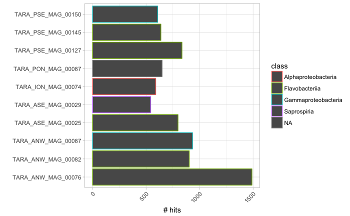

```r
# factors
#m_vs_u_mag_n$MAG <- factor(m_vs_u_mag_n$MAG, levels = (m_vs_u_mag_n %>% arrange(desc(n))))
# Plot MAGs with the most EU content
ggplot((m_vs_u_mag_n %>% filter(MAG %in% m_vs_u_mag_n_25)), aes(MAG, n, color = class)) +
  geom_bar(stat = "identity") +
  theme_light() +
  coord_flip() +
  xlab("") +
  ylab("# hits") +
  theme(axis.text.x = element_text(angle = 45, hjust = 1))
```

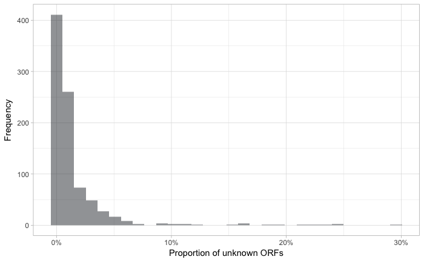

Most of the the MAGs have a low percentage of EUs in their genomic content.